# Weather Station Trends: Arizona

3/23/2022

## Data Source and Procedures

### Open Source Software & Publicly Available Data

- GSOM (Global Summary of Monthly Data)
- Analysis and Graphics R/Rstudio
- Selected Station with longest records and fewest missing data
- Select month had strongest trend
- Evaluate Monthly Temp. Max and Min for trends

## Results

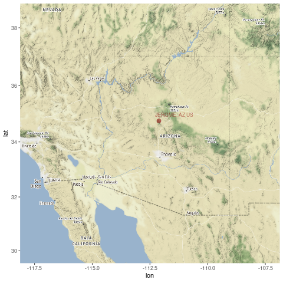

## Results

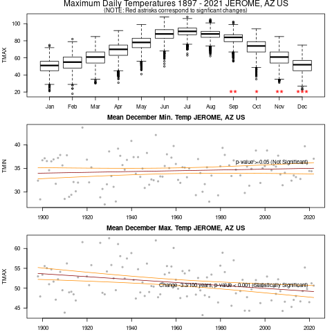

[Link to Gif](https://marclos.github.io/Climate_Change_Narratives/Social_Media/gif/Arizona_GSOM.gif)

## Impacts

- Arizona has warmed about two degrees (F) in the last century.
- Throughout the southwestern United States, heat waves are becoming more common, and snow is melting earlier in spring. - In the coming decades, changing the climate is likely to decrease the flow of water in the Colorado River, threaten the health of livestock, increase the frequency and intensity of wildfires, and convert some rangelands to desert.

[EPA Snapshot](https://19january2017snapshot.epa.gov/sites/production/files/2016-09/documents/climate-change-az.pdf)

## State Adaptation / Mitigation Plans

- Arizona has not developed a statewide adaptation plan.
- Arizona Climate and Health Adaptation Plan 2017 Public health April 2017
- Arizona DOT Resilience Pilot Program Emergency preparedness, Transportation August 2015
- Arizona Extreme Weather, Climate and Health Profile Report Public health, Frontline Communities March 2015
- Preliminary Study of Climate Adaptation for the Statewide Transportation System in Arizona Emergency preparedness, Land use and built environment, Transportation March 2013
- Arizona Wildlife Action Plan 2012-2022 Biodiversity and ecosystems, Wildlife May 16, 2012

[Source: Georgetown Climate Center] (https://www.georgetownclimate.org/adaptation/state-information/arizona/overview.html)